# Findings: Data viz in psych sci – PSYCH 490.007

Published

November 18, 2026

## About

This page extracts information about the data visualizations we explored in Exercise-01 from the shared Google Sheet.

## Survey

Direct link: https://docs.google.com/spreadsheets/d/1Q9xYmkvXsETfTHZjGXWxQ3vM2TBVWWo3Jimfv1Bkvfw/edit?gid=0#gid=0

## Preparation

First, we load the external packages (groups of R commands) that we will be using.

**Important**

The code uses the `quietly()` function from the `purrr` package to suppress most of the feedback.

```r
library('ggplot2')
library('dplyr')

r_functions <- list.files(file.path(here::here(), "R"), "\\.R$", full.names = TRUE)

purrr::map(r_functions, source) |>
  purrr::quietly()
```

[output not shown]

## Gathering

Next, we download the data from the Google Sheet where it is collected. Dr. Gilmore has stored his Google account credentials in a special environment file that can be accessed by the R command `Sys.getenv("GMAIL_SURVEY")`.

**Tip**

It’s vital to be *very* careful when creating and sharing code like this that involves sensitive information like login credentials.

```
GMAIL_SURVEY="<my-google-account>"
```

Here, he has substituted his Google account with credentials/access to the required files for `<my-google-account>`. Then, when the R code below calls `Sys.getenv("GMAIL_SURVEY")`, the value of those credentials is returned as a text string.

Make sure to close and save the `.Renviron` file and restart your R session before testing this yourself.

```r
if (!dir.exists('csv')) {
  message("Creating missing `csv/`.")
  dir.create("csv")
}

if (params$update_data) {
  options(gargle_oauth_email = Sys.getenv("GMAIL_SURVEY"))
  googledrive::drive_auth()

  googledrive::drive_download(
    "PSYCH-490.007-2026-Fall-Psych-Viz",
    path = file.path("csv", params$fn),
    type = "csv",
    overwrite = TRUE
  )
  message("Data updated.")
} else {
  message("Using stored data.")
}
```

The data file has been saved as a comma-separated value (CSV) format data file in a special directory called `csv/`.

**Note**

Because these data *might* contain sensitive or identifiable information, we only keep a local copy and do not share it publicly via GitHub. This is achieved by adding the name of the data directory to a special `.gitignore` file.

## Cleaning

Next we load the saved data file, and then proceed to clean it.

```r
ex01 <-
  readr::read_csv(file.path("csv", params$fn), show_col_types = FALSE)
```

There are 93 responses.

These are the column/variable names.

```r
# Google Forms puts the full question in the top row of the data file.
# We use the names() function to extract and print the original questions.
ex01_qs <- names(ex01)
ex01_qs
```

```
[1] "identifier"    "source_type"   "url_to_src"    "why_selected"
[5] "comment"       "other"         "url_to_figure"
```

For simplicity, we visualize below only those with non-empty URLs to the specific figure.

## Summary data

```r
figs_w_urls <- ex01 |>
  filter(!is.na(url_to_figure))
```

## Figures found

```r
these_figs <- ex01 |>
  filter(!is.na(url_to_figure))

res <- invisible(lapply(1:dim(these_figs)[1], return_img_chunk, df = these_figs))
cat(unlist(res), sep = "\n")
```

### Figure 1

**Source**: https://www.psychologicalscience.org/observer/teaching-current-directions-in-psychological-science-27#lives

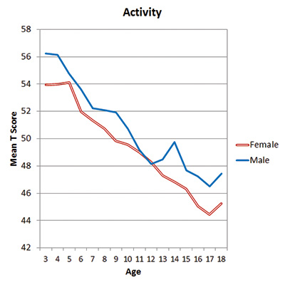

| Analyst | Source Type | Why Selected |
| --- | --- | --- |
| rog1 | web_site | NA |

| Comments |
| --- |
| NA |

### Figure 2

**Source**: https://journals.sagepub.com/doi/full/10.1177/21677026241301298

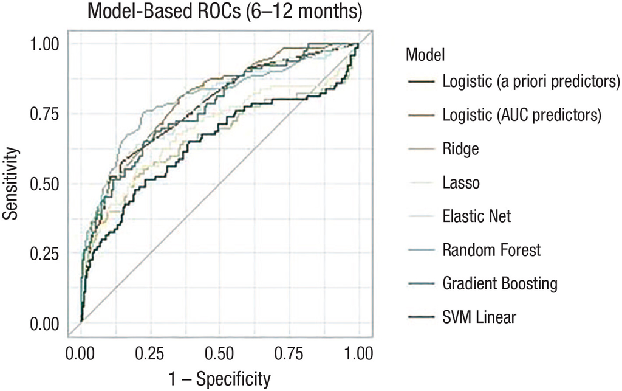

| Analyst | Source Type | Why Selected |
| --- | --- | --- |
| rog1 | article | ROC figures are used only in specialized contexts |

| Comments |
| --- |
| More info about sensitivity and specificity: https://en.wikipedia.org/wiki/Sensitivity_and_specificity |

### Figure 3

**Source**: https://doi.org/10.2147/prbm.s529004

[figure not shown]

| Analyst | Source Type | Why Selected |
| --- | --- | --- |
| kalvin1 | article | Curvilinear graphs are interesting! |

| Comments |
| --- |
| Relationship between fear intensity and enjoyment - moderately intense fear is more enjoyable than low or high intensity fear |

### Figure 4

**Source**: https://www.apa.org/pubs/reports/practitioner/2023-psychologist-reach-limits

[figure not shown]

| Analyst | Source Type | Why Selected |
| --- | --- | --- |
| ganiya | report | compares two different datasets |

| Comments |
| --- |
| percentage of psychologist reporting an increase in their patients mental health conditions |

### Figure 5

**Source**: https://spsp.org/news/character-and-context-blog/liu-dubey-a-better-way-to-talk-about-climate-change

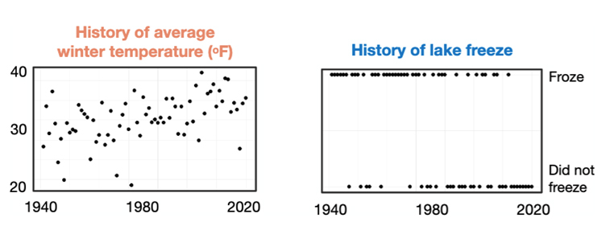

| Analyst | Source Type | Why Selected |
| --- | --- | --- |
| ganiya | article | scatter plot between two different datasets |

| Comments |
| --- |
| a better way to talk about climate change |

### Figure 6

**Source**: https://featuredcontent.psychonomic.org/so-long-for-now-thinking-back-on-our-digital-journey/

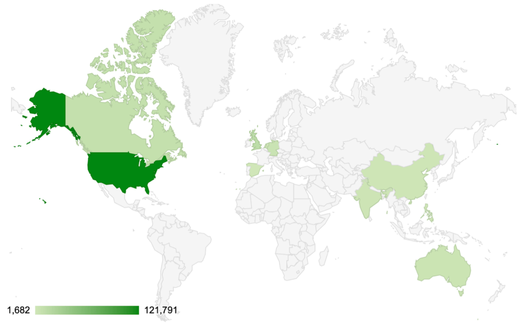

| Analyst | Source Type | Why Selected |
| --- | --- | --- |
| ganiya | article | shows a map graph to explain |

| Comments |
| --- |
| So long: thinking back on our digitial journey |

### Figure 7

**Source**: https://www.science.org/doi/10.1126/sciimmunol.aec9853

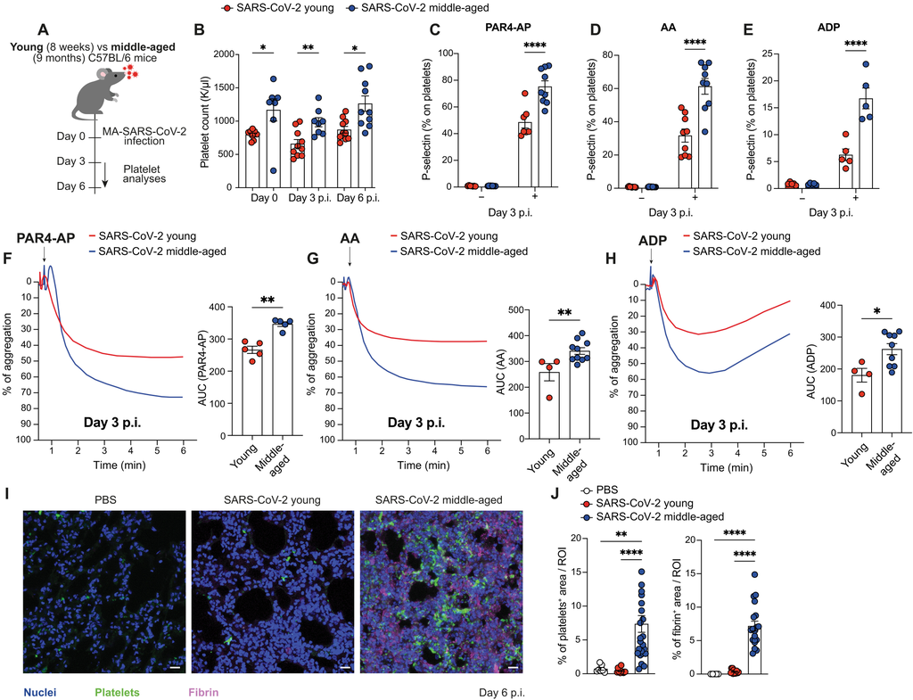

| Analyst | Source Type | Why Selected |
| --- | --- | --- |
| ganiya | research article | it highlights several types of graphs for the data |

| Comments |
| --- |
| Platelet-derived serotonin drives age-related lung pathology in SARS-CoV-2 infection |

### Figure 8

**Source**: https://www.cell.com/patterns/fulltext/S2666-3899(23)00270-2

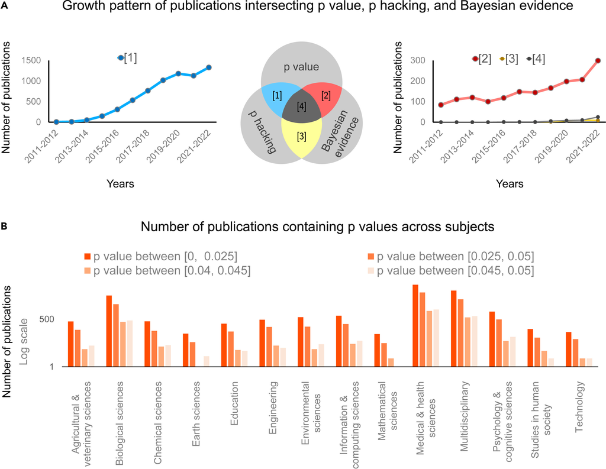

| Analyst | Source Type | Why Selected |
| --- | --- | --- |
| ganiya | research article | shows research and results over time |

| Comments |
| --- |
| The roles, challenges, and merits of the p value |

### Figure 9

**Source**: https://www.nature.com/articles/d41586-026-02469-6

[figure not shown]

| Analyst | Source Type | Why Selected |
| --- | --- | --- |
| ganiya | article | scatter plot with several datasets |

| Comments |
| --- |
| Vaporization trick enables ‘tandem’ solar cells to be made at lower temperatures |

### Figure 10

**Source**: https://journals.sagepub.com/doi/10.1177/21677026251365933

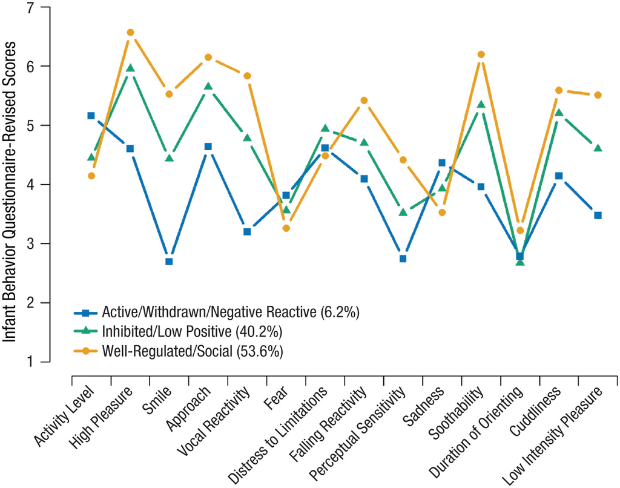

| Analyst | Source Type | Why Selected |
| --- | --- | --- |
| George | Article | Plots out behaviors and types of children in a nominal way |

| Comments |
| --- |
| Interest in the comparison between a questionnaire and personality |

### Figure 11

**Source**: https://academic.oup.com/chidev/article/97/5/1458/8499506

[figure not shown]

| Analyst | Source Type | Why Selected |
| --- | --- | --- |
| George | Article | Rather than separate out into one categorization, allows different types of characterizations |

| Comments |
| --- |
| Also a comparison to a Harvard Study in results |

### Figure 12

**Source**: https://psycnet.apa.org/fulltext/2024-78627-001.pdf?auth_token=1875ac169bf3391e4e21111bd71257e4b9ebb8d2

[figure not shown]

| Analyst | Source Type | Why Selected |
| --- | --- | --- |
| George | Article | Interesting visual for brain sensation |

| Comments |
| --- |
| There is both a graph and a visual with heads to signify the brain responses |

### Figure 13

**Source**: https://www.nature.com/articles/s41539-025-00386-3?fromPaywallRec=true

[figure not shown]

| Analyst | Source Type | Why Selected |
| --- | --- | --- |
| George | Journal | A visualization to show the sequence participants were asked to use |

| Comments |
| --- |
| It allows others to follow what was done simply from a visual glance, not reading a paragraph of text |

### Figure 14

**Source**: https://www.cell.com/trends/cognitive-sciences/fulltext/S1364-6613(21)00051-6

[figure not shown]

| Analyst | Source Type | Why Selected |
| --- | --- | --- |
| George | Journal | Compares on multiple levels of understanding vs. belief |

| Comments |
| --- |
| Compares the belief and discernment of fake news from viewers |

### Figure 15

**Source**: https://www.annualreviews.org/content/journals/10.1146/annurev-psych-010418-103408#dataandmedia

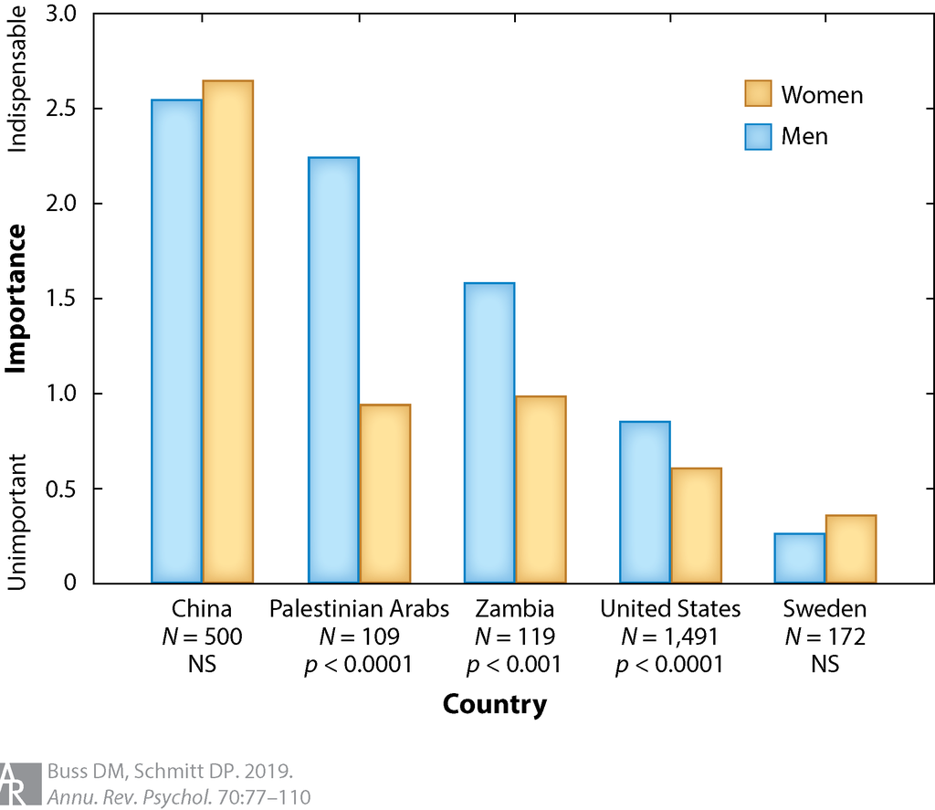

| Analyst | Source Type | Why Selected |
| --- | --- | --- |
| George | Journal | The vast range the bar graphs encompass |

| Comments |
| --- |
| Importance of spouces with no prior intercourse |

### Figure 16

**Source**: https://direct.mit.edu/jocn/article/38/5/1055/134299/From-Forest-to-Focus-The-Interactive-Effects-of

[figure not shown]

| Analyst | Source Type | Why Selected |
| --- | --- | --- |
| Gabbi | Journal | Comparison of data sets and shading of confidence interval is interesting! |

| Comments |
| --- |
| Study utilizes EEGs and other methods to investigate effects of nature on attention and mood |

### Figure 17

**Source**: https://journals.sagepub.com/doi/10.1177/09567976261453813

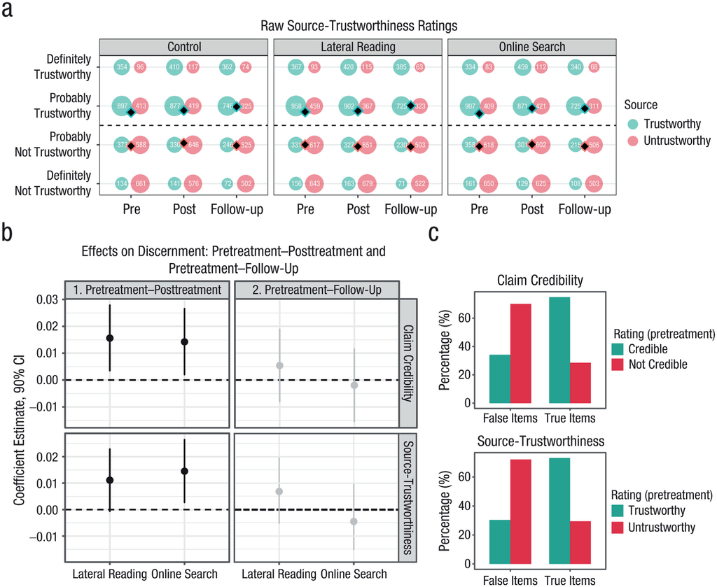

| Analyst | Source Type | Why Selected |
| --- | --- | --- |
| Gabbi | Journal | The combination of the dot plot, dot and whisker plot, and bar chart into its own figure made up of sub-panels is extremely effective! |

| Comments |
| --- |
| Study about different methods for improving media literacy in adults |

### Figure 18

**Source**: https://www.psychologicalscience.org/journals/psychological-science/09567976261461126/

[figure not shown]

| Analyst | Source Type | Why Selected |
| --- | --- | --- |
| Gabbi | Journal | Jittered scatter plot with mean error bars |

| Comments |
| --- |
| Study about reduced mental health in parents of transgender youth after 2025 Presidential Inauguration |

### Figure 19

**Source**: https://onlinelibrary.wiley.com/doi/10.1111/jora.12581

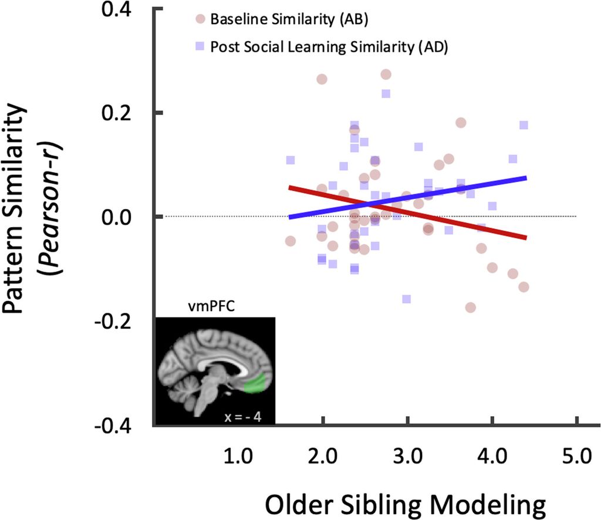

| Analyst | Source Type | Why Selected |
| --- | --- | --- |
| Gabbi | Journal | Integrated MRI photo for clarity was an interesting choice that I have never seen before |

| Comments |
| --- |
| Study about how older sibling risk taking behavior impacts younger siblings |

### Figure 20

**Source**: https://pubmed.ncbi.nlm.nih.gov/39343080/

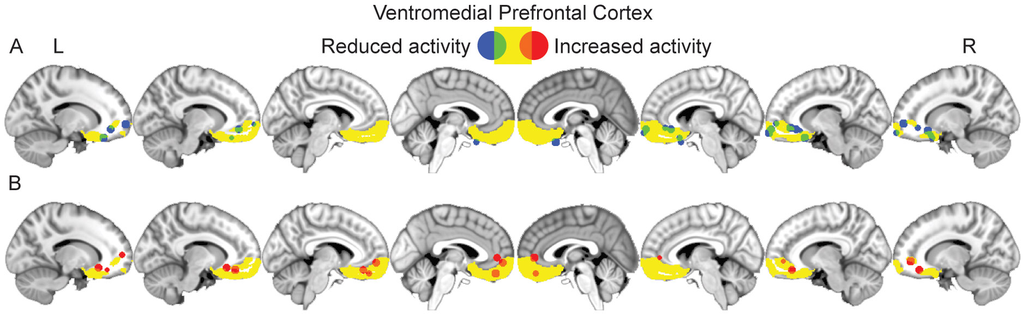

| Analyst | Source Type | Why Selected |
| --- | --- | --- |
| Gabbi | Journal | Combining MRI scans side by side into one figure is much easier to read than having them as their own individual photos (which is more common in my experience) |

| Comments |
| --- |
| Systematic review of studies interested in connection between psychopathy and brain activity |

### Figure 21

**Source**: https://pubmed.ncbi.nlm.nih.gov/26483461/

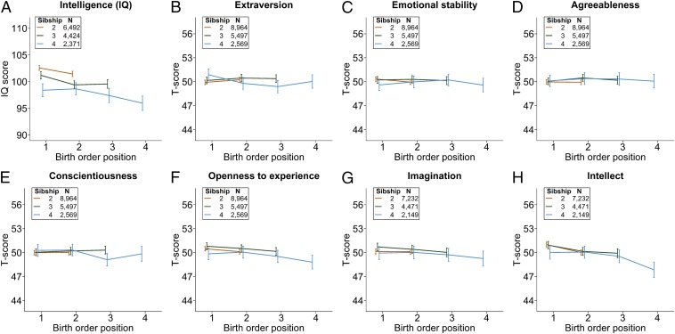

| Analyst | Source Type | Why Selected |
| --- | --- | --- |
| Gabbi | Journal | Combining the line graphs makes for an easy side-by-side comparison and is particularly helpful for data like this |

| Comments |
| --- |
| Study about how sibling order and family size effects personality and intelligence |

### Figure 22

**Source**: https://www-sciencedirect-com.ezaccess.libraries.psu.edu/science/article/pii/S019745801600213X#

[figure not shown]

| Analyst | Source Type | Why Selected |
| --- | --- | --- |
| Minjoo | journal | They used scatter plot with a bar that represents mean value |

| Comments |
| --- |
| successful associative memory encoding |

### Figure 23

**Source**: https://www-sciencedirect-com.ezaccess.libraries.psu.edu/science/article/pii/S0028393222001166

[figure not shown]

| Analyst | Source Type | Why Selected |
| --- | --- | --- |
| Minjoo | journal | Using scatter plot in the bar graph is interesting |

| Comments |
| --- |
| emoitonal schema effects on associative memory across different emotion |

### Figure 24

**Source**: https://www-sciencedirect-com.ezaccess.libraries.psu.edu/science/article/pii/S0304394012015133

[figure not shown]

| Analyst | Source Type | Why Selected |
| --- | --- | --- |
| Minjoo | journal | It was interesting that they used both line and bar graph to interpret brain activity |

| Comments |
| --- |
| pragmatic inferences modulate N400 during sentence comprehension |

### Figure 25

**Source**: https://journals.sagepub.com/doi/abs/10.1177/21677026241301298

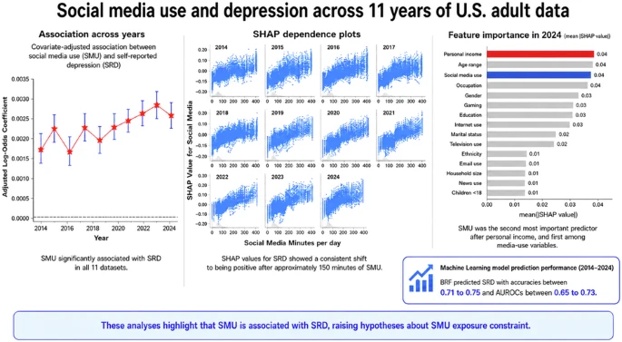

| Analyst | Source Type | Why Selected |
| --- | --- | --- |
| Minjoo | article | The topic itself was interesting, and the data shows how their association increases throughout the years |

| Comments |
| --- |
| social media use and depression |

### Figure 26

**Source**: https://www.nature.com/articles/s44184-026-00228-z

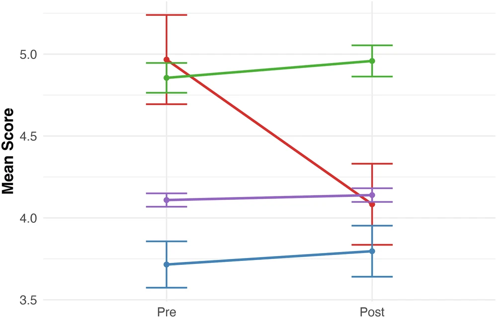

[output not shown]

| Comments |
| --- |
| personality changes following first-time psychedelic use |

### Figure 27

**Source**: https://www.nature.com/articles/s44184-025-00173-3

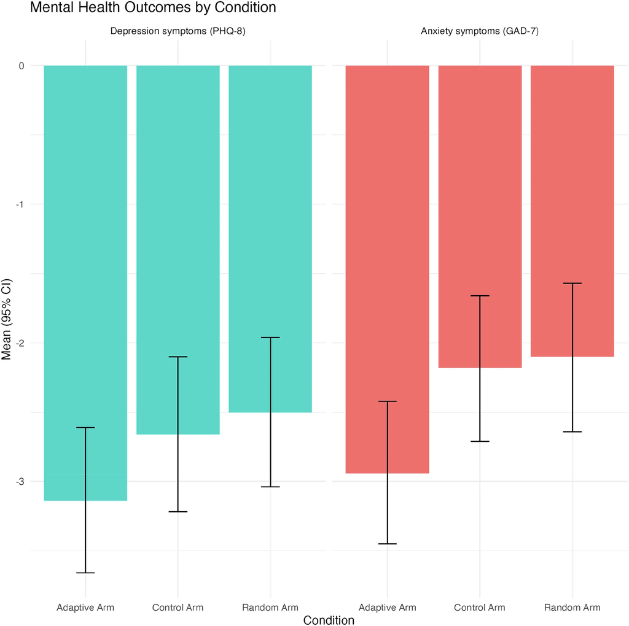

| Analyst | Source Type | Why Selected |
| --- | --- | --- |
| Minjoo | article | Using different colors for bars gives clear distinction between two symptoms |

| Comments |
| --- |
| mental health texting intervention using reinforcement learning |

### Figure 28

**Source**: https://www.researchgate.net/publication/374739075_Research_on_the_influence_of_physical_games_in_the_process_of_preschool_children's_psychological_development

[figure not shown]

| Analyst | Source Type | Why Selected |
| --- | --- | --- |
| Elizabeth | Article | I found this topic intersting also the graph seemed to really by having both bar and line graph |

| Comments |
| --- |
| NA |

### Figure 29

**Source**: <Sleep deprivation increases formation of false memory - Lo - 2016 - Journal of Sleep Research - Wiley Online Library>

[figure not shown]

| Analyst | Source Type | Why Selected |
| --- | --- | --- |
| Elizabeth | Article | NA |

| Comments |
| --- |
| NA |

### Figure 30

**Source**: https://www.pnas.org/doi/10.1073/pnas.2516655123

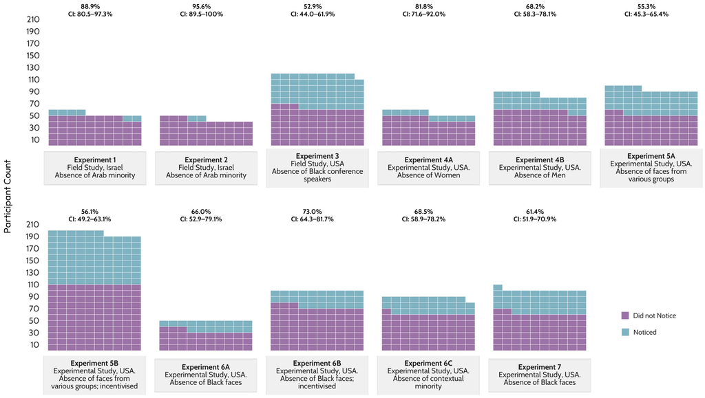

| Analyst | Source Type | Why Selected |
| --- | --- | --- |
| Daniel | Article | They use a pictogram chart to represent blindness to absence of minority groups |

| Comments |
| --- |
| They use a pictogra, chart to represent blindness to absence of minority groups |

### Figure 31

**Source**: https://www.sciencedirect.com/science/article/pii/S2214782925000570?via%3Dihub#s0040

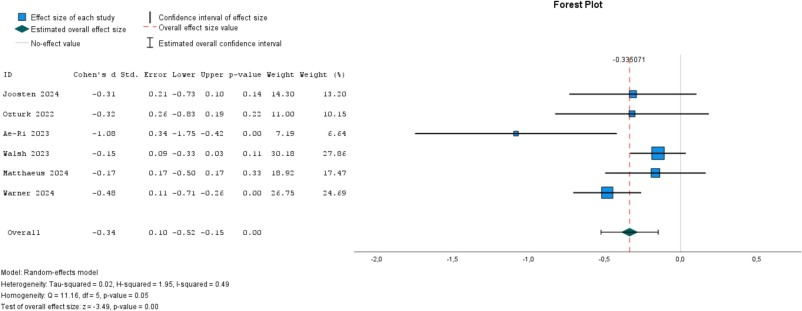

| Analyst | Source Type | Why Selected |
| --- | --- | --- |
| Daniel | Article | The topic is interesting and it compares and looks at data from a lot of different studies |

| Comments |
| --- |
| Compares different psychological interventions on loneliness |

### Figure 32

**Source**: https://www.apa.org/pubs/reports/stress-in-america/2025

[figure not shown]

| Analyst | Source Type | Why Selected |
| --- | --- | --- |
| Daniel | Website | The bar chart serves as a great help to visualize how many people are reporting the different signs of loneliness and put it into perspective for the reader |

| Comments |
| --- |
| Shows adult reports in the United States on lonliness |

### Figure 33

**Source**: https://www.pnas.org/doi/full/10.1073/pnas.2105061118

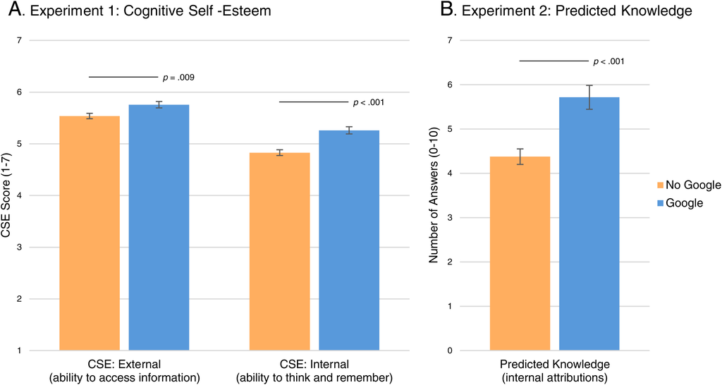

| Analyst | Source Type | Why Selected |
| --- | --- | --- |
| Daniel | Article | I found the topic at hand interesting and the bar chart also represents the findings in a way that is easier to understand |

| Comments |
| --- |
| The bar chart has two 2 experiments of the study in the chart making it so that one can compare and understand the two more easily. |

### Figure 34

**Source**: https://journals.sagepub.com/doi/full/10.1177/0956797618774253

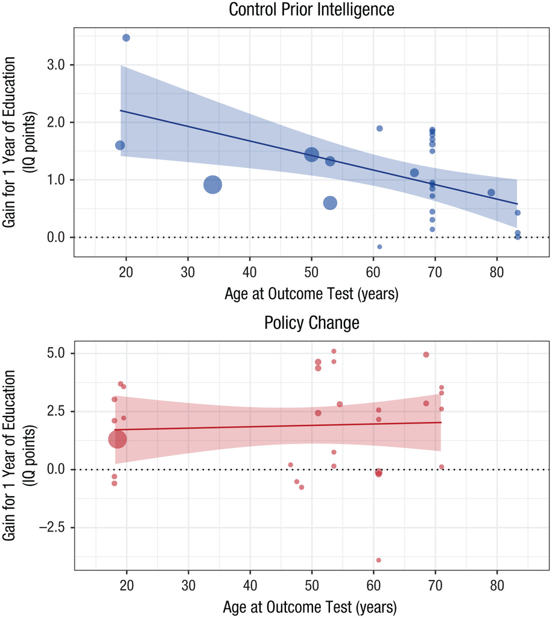

| Analyst | Source Type | Why Selected |
| --- | --- | --- |
| Daniel | Article | Have never seen a scatter plot presented in this manner |

| Comments |
| --- |
| It is actually 2 scatter plots comparing the control group with the one that did have changes, making it an interest visualization to look at and look at the differences in data |

### Figure 35

**Source**: https://link.springer.com/article/10.1007/s40593-025-00521-6

[figure not shown]

| Analyst | Source Type | Why Selected |
| --- | --- | --- |
| Daniel | Article | Topic was interesting and I wanted to see how thye would be able to visualize their findings |

| Comments |
| --- |
| It shows the mean grades from the 1st assignment and 5th assignment, comparing what effects the LLMs had on the mean grades for each aspect measured. |

### Figure 36

**Source**: https://academic.oup.com/chidev/article/97/4/1068/8653055

[figure not shown]

| Analyst | Source Type | Why Selected |
| --- | --- | --- |
| jackson | article | compares performance across multiple differnet statistical learning tasks |

| Comments |
| --- |
| comopares the trajectory of statisitcal learning of children across a number of different task s |

### Figure 37

**Source**: https://www.apa.org/monitor/2025/11-12/ai-use-early-career-psychologists

[figure not shown]

| Analyst | Source Type | Why Selected |
| --- | --- | --- |
| Maria/Elaina/olivia | Article | Clearly compares AI use among psychologists at different career stages |

| Comments |
| --- |
| Shows the frequency of AI use in the past 12 months by career stage in 2024. |

### Figure 38

**Source**: https://spsp.org/news-center/character-context-blog/look-sunny-side-optimism-increases-people-get-older

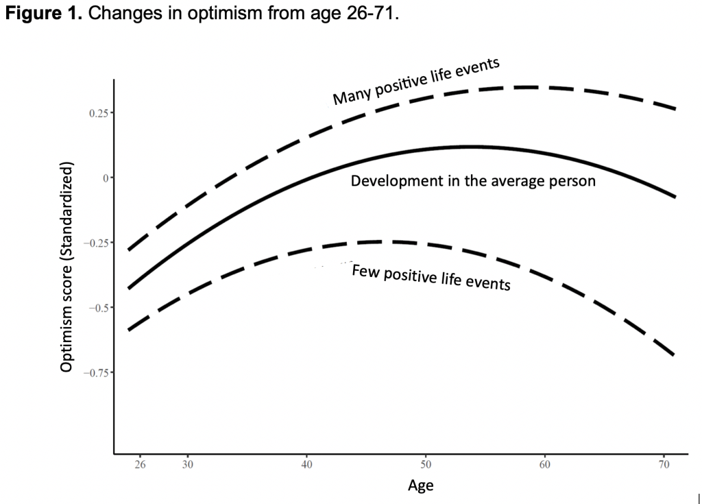

| Analyst | Source Type | Why Selected |
| --- | --- | --- |
| Maria/Elaina/olivia | Article | I found this graph really interesting because it shows how optimism changes as people get older. |

| Comments |
| --- |
| Shows that optimism increases in middle age, then decreases later in life depending on positive life events. |

### Figure 39

**Source**: https://www.cdc.gov/nchs/products/databriefs/db513.htm

[figure not shown]

| Analyst | Source Type | Why Selected |
| --- | --- | --- |
| Maria/Elaina/olivia | Article | I found this graph interesting because social media continues to grow and this shows that about half of teenagers spend 4 or more hours a day on screens. |

| Comments |
| --- |
| Shows the difference in percentage of screen time in teenagers aged 12-17 |

### Figure 40

**Source**: https://www.apa.org/monitor/2024/01/trends-pathways-access-mental-health-care

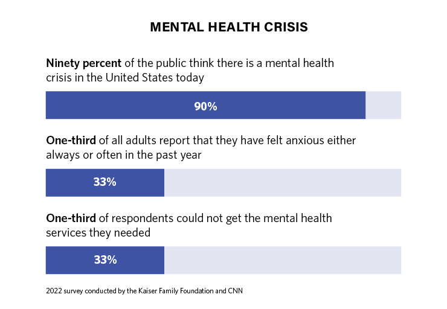

| Analyst | Source Type | Why Selected |
| --- | --- | --- |
| Aiden/Luana | Article | The bar graph used is unique in its incredible way to relay information on mental health within different sectors |

| Comments |
| --- |
| Outlines mental health issues broadly, specifically, and how a need for a solution exists |

### Figure 41

**Source**: https://www.niaaa.nih.gov/alcohols-effects-health/alcohol-topics-z/alcohol-facts-and-statistics/alcohol-and-older-adults-ages-65

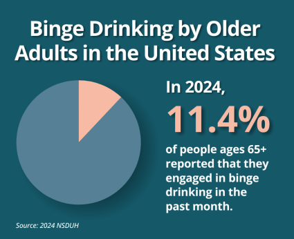

| Analyst | Source Type | Why Selected |
| --- | --- | --- |
| Aiden/Luana | Web_site | This pie chart makes visualizing the issues being discussed very easy to understand for viewers and covers and interesting topic |

| Comments |
| --- |
| Percent of elederly that consider themselves binge drinkers |

### Figure 42

**Source**: https://link.springer.com/article/10.1007/s40519-026-01855-3

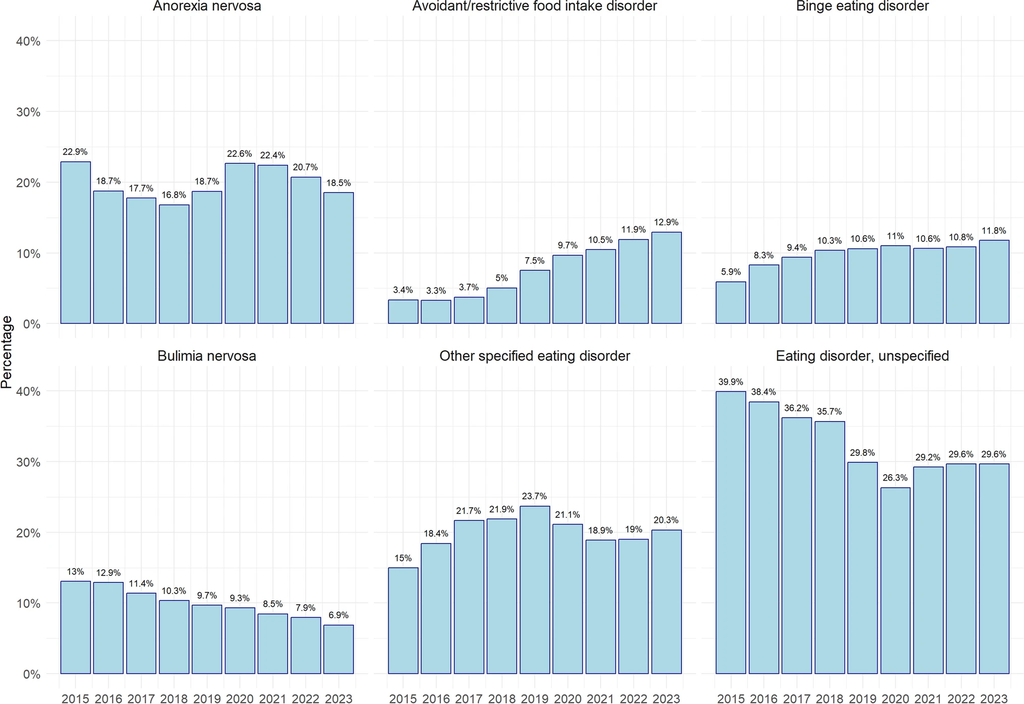

| Analyst | Source Type | Why Selected |
| --- | --- | --- |
| Aiden/Luana | Empirical Journal | I used this bar chart because I think it covers a very relevant and erious topic and is multifacted in the data it presents |

| Comments |
| --- |
| Trends in eating disorders over a recent 8 year span |

### Figure 43

**Source**: https://onlinelibrary.wiley.com/doi/10.1111/jora.70224

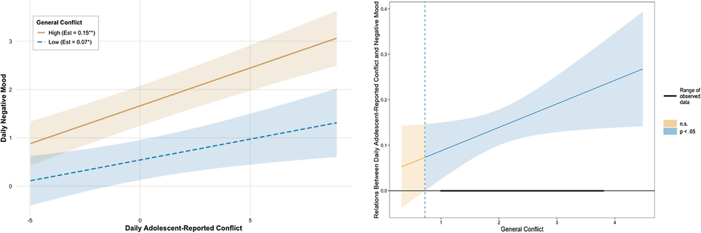

| Analyst | Source Type | Why Selected |
| --- | --- | --- |
| Aiden/Luana | empirical article | I find this area of psychology, adolescent psych, one of the most intresting topics in this field. This article evaluates parent-adolescent relationships as context for daily relations and mood |

| Comments |
| --- |
| the left graph shows the conflict sensitization while the right graph shows the widespread effect |

### Figure 44

**Source**: https://academic.oup.com/chidev/article/97/5/1502/8550827

[figure not shown]

| Analyst | Source Type | Why Selected |
| --- | --- | --- |
| Aiden/Luana | journal article | I found the topic very intresting and they use dfferent kinds of graphs to depict changes in young childrens behavior after COVID-19 |

| Comments |
| --- |
| shows how four year old childrens scores in Pittsburgh, PA increased after the pandemic on all five behavioral problems |

### Figure 45

**Source**: https://psycnet.apa.org/fulltext/2022-16907-001.html

[figure not shown]

| Analyst | Source Type | Why Selected |
| --- | --- | --- |
| Aiden/Luana | journal article | Uses multiple types of graphs and figures to help better understand whether caregivers are able to integrate stimulus avoidance assesment procedures while still maintaining fidelity |

| Comments |
| --- |
| this graph shows us the difference between results based on who adminstered the procedures, the impact this had on destructive behavior, and the clinical implementation |

### Figure 46

**Source**: https://psycnet.apa.org/fulltext/2026-89350-001.pdf

[figure not shown]

| Analyst | Source Type | Why Selected |
| --- | --- | --- |
| Arnesh | Article | This forest plot shows effect sizes grouped up in 3 different mental illiness groups, which is very interesting to see |

| Comments |
| --- |
| Plots data from multiple studies into the forest plot |

### Figure 47

**Source**: https://www.siop.org/tip-article/use-of-artificial-intelligence-in-industrial-organizational-psychology-current-trends-and-future-outlook-2/

[figure not shown]

| Analyst | Source Type | Why Selected |
| --- | --- | --- |
| Callie | Article | I selcted this graph because I am interested in I-O psychology and the future of AI |

| Comments |
| --- |
| Frequency of Use of GenAI Across All Participants |

### Figure 48

**Source**: https://www.apa.org/pubs/journals/releases/law-0000037.pdf

[figure not shown]

| Analyst | Source Type | Why Selected |
| --- | --- | --- |
| Callie | Journal Article | I selected this graph because it relates to colleges and universities |

| Comments |
| --- |
| Crimes reported on cmapus throughout the years in relation to the audit |

### Figure 49

**Source**: https://www.apa.org/pubs/journals/features/sgd-0000050.pdf

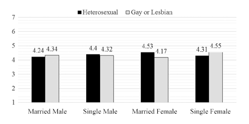

| Analyst | Source Type | Why Selected |
| --- | --- | --- |
| Callie | Journal Article | I was curious to see the biases in the hiring proccess and it relates to the field I want to go into |

| Comments |
| --- |
| Three-way interaction between sexual orientation, marital status, and gender. |

### Figure 50

**Source**: https://www.annualreviews.org/content/journals/10.1146/annurev-psych-122216-011911

[figure not shown]

| Analyst | Source Type | Why Selected |
| --- | --- | --- |
| Callie | Article | I was curious to understand more about the graph and because I enjoy learning about attitudes. |

| Comments |
| --- |
| Showing the proportion of attitude related articles over time. It is focused on the research of attitudes not people’s attitudes |

### Figure 51

**Source**: https://www.annualreviews.org/content/journals/10.1146/annurev-psych-010418-103408

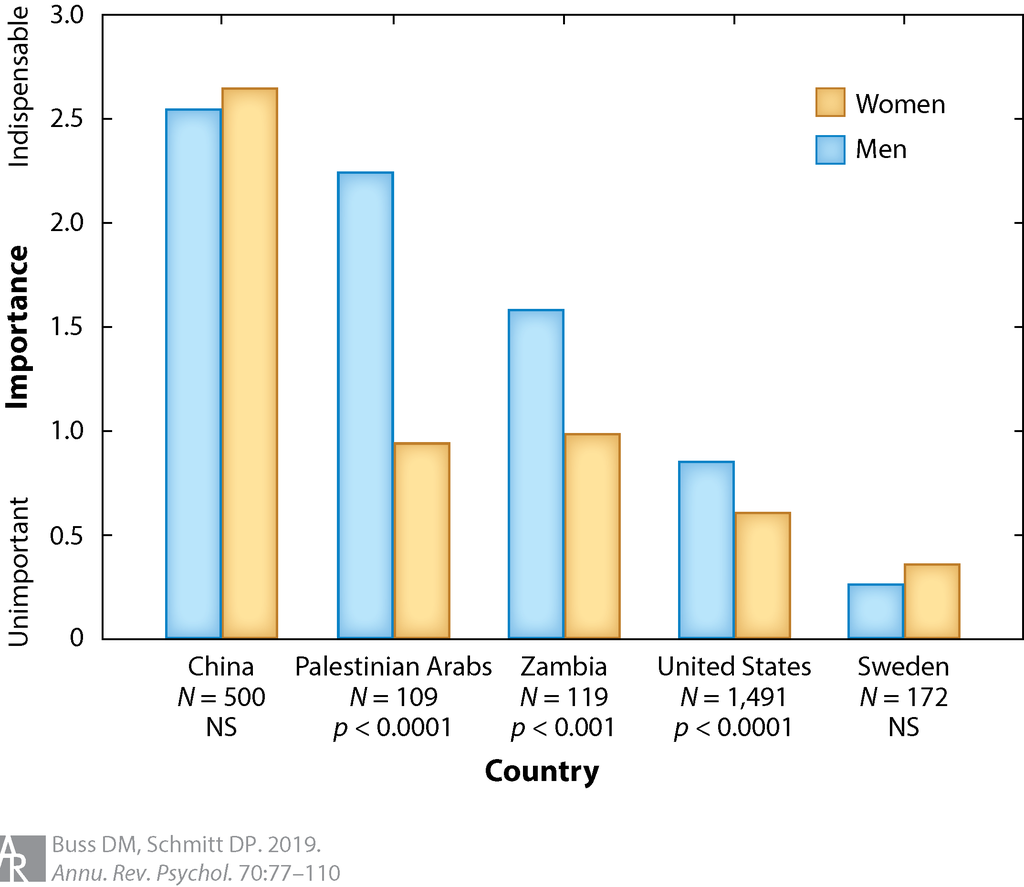

| Analyst | Source Type | Why Selected |
| --- | --- | --- |
| Callie | Article | I found this graph interesting because it included multiple different countries and both male and female preferences in spouse |

| Comments |
| --- |
| Shows the importance of no sexual intercourse in a potential spouse between different countries |